# Instruction

Welcome,  
**Please read the following instructions carefully. This task can make you win a bonus from 0$ to more than 30$.**

## Bonus

Your bonus will be calculated according to the lotteries that you will choose. You will choose 100 lotteries on a screen and one of them will be randomly picked by the computer. The randomly picked lottery will be played out and determine your bonus.

## Lottery

You choose your preferred lottery by choosing a number between 0 and 64 in the corresponding box.

This number represents simultaneously the amount you can win and the probability you have to win.

The amount you can win will be the number you choose multiplied by 0.5$. The probability you have to win is (64 - n)/64, with n the number you choose. The higher the amount you can win, the lower the probability that you win. In order to help you, your chances of winning for the selected amount will be clearly indicated on the right hand side of your screen, next to the place where you input your choice.

An example is shown below:

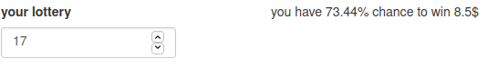

lottery choice

## Task timeline

The task will proceed as follows:

1. **Questionnaire** We ask you to answer few question.
2. **Testing** You can then test how you will choose your lotteries and how the software interface will present the results on 10 lotteries. This test phase will not be relevant for the bonus.
3. **Bonus** You will then be able to choose the 100 lotteries that will allow you to increase your bonus.
4. **Result** You have to answer some additional questions and your results will be displayed along with instructions on how to fill in the necessary information to complete the Mechanical Turk Task.

We remind you that in case of disconnection, you can go back to where you were by entering your login and password on the login page.

If the instructions are clear to you, you can proceed to the next step by pressing the button below.